# **Analyses for individual differences study**

# Introduction

## Project Aim

This project is part of a postgraduate dissertation investigating whether infant vocabulary size at 17 months can be predicted from infant prelinguistic communication and caregiver responses at 12 months (https://osf.io/t4r3u).

The 12-month data was coded from 5-minute video recordings of caregiver-infant interactions at home. Infant vocabulary size data was collected from parent responses to the MacArthur Communicative Development Inventories (CDI). The 12-month data was collected from 125 families, 122 of which provided responses to the MacArthur CDI at 17 months. These families were part of a wider RCT investigating the effectiveness of an online parent-focused intervention using resources from the BBC’s Tiny Happy People Programme (https://osf.io/kme68/).

## Project Organisation

The /raw folder contains the raw data used for this project and /figs contains the figures produced from this project.

A codebook can be found in the /raw folder, which describes the dataset that is used for this project.

## Loading packages

```r
#renv - Store packages and keep account of package versions
if (!require('renv'))
{
  install.packages('renv');
}
library(renv)
renv::restore()

# Load packages
library(AER) #conduct an overdispersion test on Poisson Models
library(here) #locate files based on current working directory
library(MASS) #Fit negative binomial regression
library(MuMIn) #Calculate the Akaike Information Criterion (AIC) for each model
library(pastecs) # Provides useful descriptive statistics
library(tidyverse) #Data analysis, management, and visualisation
library(WebPower) #Conduct power analysis
library(psych) #Conduct the reliability check
library(iccCounts) #Conduct the reliability check
```

## Load the data

Loading the dataset from the current working directory.

PLEASE NOTE: The csv file in the R code (“SCC_ID_data_UNBLINDED_stage1.csv”) is different from the csv file uploaded to Github (“SCC_ID_data_blinded_stage1.csv”). The unblinded dataset was not shared via Github as it contained data relating to participant condition. Openly sharing this data would risk unblinding research assistants who are working on the full RCT which this project is using data from. Therefore, the blinded dataset (without participant condition) is shared instead.

```r
# Load the dataset
df <- read.csv(here("raw", "SCC_ID_data_UNBLINDED_stage1.csv"))

stat.desc(df) #provides descriptive statistics for variables in dataset
```

## Prospective Power Analysis

A prospective power analysis was conducted to determine whether the sample size of this study was sufficient to detect a small-medium effect size. The median of “seventeen_cdi_vocab_count” is used as the baseline rate to ensure that we have an accurate calculation of the sample size that would have been needed to detect a small/medium effect size.

```r
baselinerate = median(df$seventeen_cdi_vocab_count, na.rm = TRUE) #Baseline rate of infant vocab size

#Small effect size

d=0.2

# Calculating the expected slope based on an effect size of 0.2

lo=d*(pi/sqrt(3))

increase = exp(lo)

slope=(baselinerate+increase)/baselinerate

# Conducting the power analysis with 80% power and 0.2 effect size

wp.poisson(n = NULL, exp0 = baselinerate, exp1 = slope, alpha = 0.05, power = 0.8, family = "Bernoulli", alternative="greater")
```

```
## Power for Poisson regression
##
##           n power alpha exp0     exp1    beta0      beta1
##     272.061   0.8  0.05   22 1.065331 3.091042 0.06328592
##
## URL: http://psychstat.org/poisson
```

```r
#Medium effect size

d=0.5

# Calculating the expected slope based on an effect size of 0.5

lo=d*(pi/sqrt(3))

increase = exp(lo)

slope=(baselinerate+increase)/baselinerate

# Conducting the power analysis with 80% power and 0.5 effect size

wp.poisson(n = NULL, exp0 = baselinerate, exp1 = slope, alpha = 0.05, power = 0.8, family = "Bernoulli", alternative="greater")
```

```
## Power for Poisson regression
##
##            n power alpha exp0     exp1    beta0     beta1
##     93.78244   0.8  0.05   22 1.112574 3.091042 0.1066764
##
## URL: http://psychstat.org/poisson
```

# Data preparation

## Preparing the researcher-coded behaviours

The below code is used to prepare the counts of researcher-coded behaviours prior to incorporating them into Poisson regression models. The code takes the columns that begin with “twelve_”, which are the columns containing the counts of researcher-coded behaviours (aside from twelve_length), and mutates them using the following steps: 1. Adding one to the counts to avoid zero counts 2. Prorating the counts by dividing them by the length of the videos at 12 months and multiplying them by 300 (the maximum length of a video) 3. Log transforming the counts to reduce skewness 4. Robust scaling by subtracting the median from each of the values and dividing by the interquartile range of each column

```r
# Proscaling and log transforming the counts
df1 <- df %>%
  mutate(across(
    starts_with("twelve_") & !matches("twelve_length"),
    ~ (log(((. + 1) / twelve_length) * 300))
  ))

# robust scaling to be done with the log transformed variables
df2 <- df1 %>%
  mutate(across(
    starts_with("twelve_") & !matches('twelve_length'),
    ~ ((. - median(.)) / IQR(.))
  ))
```

## Centering age around the mean

```r
# Centering age around the mean
df2$centered_age <- scale(df2$age_at_survey, center = TRUE, scale = FALSE)
```

## Reliability check

Since there were two coders who independently coded the 12-month data, the intraclass correlation (ICC) was calculated for the counts of each of the behaviour categories that were coded. The code below was used to determine the reliability of the coder counts for the following behaviour categories: 1) Infant intentional prelinguistic communicative acts (PCA; the total number of showing, giving, index-finger points and gaze-coordinated vocalisations) that elicited a semantically contingent (SC) response 2) Infant intentional PCAs that elicited a content-light (CL) response The reliability of the coder counts for the other four behaviour categories were calculated by Salter et al. (submitted), who conducted an analysis of the 12-month data from the full RCT. The ICC for all behaviour categories indicated good reliability (0.71 - 0.88).

```r
#PCA only reliability, SC responses
Coder1=data.frame(cbind(df$participant,df$twelve_sc_pca_only_1,rep(1,length(df$participant))))
names(Coder1) <- c("id","y","met")

Coder2=data.frame(cbind(df$participant,df$twelve_sc_pca_only_2,rep(2,length(df$participant))))
names(Coder2) <- c("id","y","met")

for_icc=data.frame(rbind(Coder1,Coder2))
ICC(icc_counts(data = for_icc,y="y",id="id",met="met",type="con"))
```

```
## Model: poisson
```

```
##            ICC    SE ICC 95% CI LL 95% CI UL
## [1,] 0.8820247 0.0624452  0.682397 0.9592189
```

```r
#PCA only reliability, CL responses
Coder1=data.frame(cbind(df$participant,df$twelve_cl_pca_only_1,rep(1,length(df$participant))))
names(Coder1) <- c("id","y","met")

Coder2=data.frame(cbind(df$participant,df$twelve_cl_pca_only_2,rep(2,length(df$participant))))
names(Coder2) <- c("id","y","met")

for_icc=data.frame(rbind(Coder1,Coder2))
ICC(icc_counts(for_icc,y="y",id="id",met="met",type="con"))
```

```
## Model: poisson
```

```
##            ICC  SE ICC 95% CI LL 95% CI UL
## [1,] 0.7761432 0.11833 0.4237818 0.9244645
```

# Data analysis

## Fitting the models to a Poisson Distribution

Building the models using poisson regressions. Each model contains infant vocabulary size at 17 months as an outcome variable (‘seventeen_cdi_vocab_count’) and condition and centered age as control variables. Aside from the null model (M0), each model also contains a predictor variable representing the total number of times a dyadic combination of an infant behaviour and caregiver response occurred within a five minute caregiver-infant interaction (e.g., “twelve_pca_count”).

### Model 0 - Null Model

```r
M0 = glm(seventeen_cdi_vocab_count ~ condition + centered_age, family = poisson, data=df2)
```

### Model 1 - Count of infant ‘intentional’ Prelinguistic Communicative Acts

```r
M1 = glm(seventeen_cdi_vocab_count ~ condition + centered_age + twelve_pca_count ,family=poisson,data=df2)

summary(M1)
```

```
##
## Call:
## glm(formula = seventeen_cdi_vocab_count ~ condition + centered_age +
##     twelve_pca_count, family = poisson, data = df2)
##
## Deviance Residuals:
##      Min        1Q    Median        3Q       Max
## -13.5310   -5.6066   -3.2318    0.6873   25.8800
##
## Coefficients:
##                    Estimate Std. Error z value Pr(>|z|)
## (Intercept)       3.8568559  0.0184918 208.571  < 2e-16 ***
## condition        -0.2113030  0.0275901  -7.659 1.88e-14 ***
## centered_age      0.0178258  0.0007318  24.359  < 2e-16 ***
## twelve_pca_count  0.2948766  0.0169657  17.381  < 2e-16 ***
## ---
## Signif. codes:  0 '***' 0.001 '**' 0.01 '*' 0.05 '.' 0.1 ' ' 1
##
## (Dispersion parameter for poisson family taken to be 1)
##
##     Null deviance: 7285.2  on 121  degrees of freedom
## Residual deviance: 6497.8  on 118  degrees of freedom
##   (3 observations deleted due to missingness)
## AIC: 7096.8
##
## Number of Fisher Scoring iterations: 6
```

### Model 2 - Count of infant ‘intentional’ Prelinguistic Communicative Acts that elicited a response of any kind

```r
M2 = glm(seventeen_cdi_vocab_count ~ condition + centered_age + twelve_responses_pca_only_count ,family=poisson,data=df2)

summary(M2)
```

```
##
## Call:
## glm(formula = seventeen_cdi_vocab_count ~ condition + centered_age +
##     twelve_responses_pca_only_count, family = poisson, data = df2)
##
## Deviance Residuals:
##      Min        1Q    Median        3Q       Max
## -13.5373   -5.5438   -3.2748    0.5125   25.7649
##
## Coefficients:
##                                   Estimate Std. Error z value Pr(>|z|)
## (Intercept)                      3.8746545  0.0185020 209.418  < 2e-16 ***
## condition                       -0.2117321  0.0275794  -7.677 1.63e-14 ***
## centered_age                     0.0174921  0.0007238  24.167  < 2e-16 ***
## twelve_responses_pca_only_count  0.5078757  0.0288249  17.619  < 2e-16 ***
## ---
## Signif. codes:  0 '***' 0.001 '**' 0.01 '*' 0.05 '.' 0.1 ' ' 1
##
## (Dispersion parameter for poisson family taken to be 1)
##
##     Null deviance: 7285.2  on 121  degrees of freedom
## Residual deviance: 6489.1  on 118  degrees of freedom
##   (3 observations deleted due to missingness)
## AIC: 7088.2
##
## Number of Fisher Scoring iterations: 6
```

### Model 3 - Count of infant ’intentional Prelinguistic Communicative Acts that elicited a content-light response

```r
M3 = glm(seventeen_cdi_vocab_count ~ condition + centered_age + twelve_cl_pca_only_count ,family=poisson,data=df2)

summary(M3)
```

```
##
## Call:
## glm(formula = seventeen_cdi_vocab_count ~ condition + centered_age +
##     twelve_cl_pca_only_count, family = poisson, data = df2)
##
## Deviance Residuals:
##     Min       1Q   Median       3Q      Max
## -12.697   -5.354   -2.967    1.244   27.759
##
## Coefficients:
##                            Estimate Std. Error z value Pr(>|z|)
## (Intercept)               3.4874914  0.0238236 146.388  < 2e-16 ***
## condition                -0.1049756  0.0273904  -3.833 0.000127 ***
## centered_age              0.0163481  0.0007293  22.417  < 2e-16 ***
## twelve_cl_pca_only_count  0.4317670  0.0155778  27.717  < 2e-16 ***
## ---
## Signif. codes:  0 '***' 0.001 '**' 0.01 '*' 0.05 '.' 0.1 ' ' 1
##
## (Dispersion parameter for poisson family taken to be 1)
##
##     Null deviance: 7285.2  on 121  degrees of freedom
## Residual deviance: 6082.5  on 118  degrees of freedom
##   (3 observations deleted due to missingness)
## AIC: 6681.5
##
## Number of Fisher Scoring iterations: 6
```

### Model 4 - Count of infant ’intentional Prelinguistic Communicative Acts that elicited a semantically contingent response

```r
M4 = glm(seventeen_cdi_vocab_count ~ condition + centered_age + twelve_sc_pca_only_count ,family=poisson,data=df2)


summary(M4)
```

```
##
## Call:
## glm(formula = seventeen_cdi_vocab_count ~ condition + centered_age +
##     twelve_sc_pca_only_count, family = poisson, data = df2)
##
## Deviance Residuals:
##      Min        1Q    Median        3Q       Max
## -14.8484   -5.6922   -3.2078    0.5332   24.6085
##
## Coefficients:
##                            Estimate Std. Error z value Pr(>|z|)
## (Intercept)               3.8312572  0.0184769 207.354  < 2e-16 ***
## condition                -0.1773695  0.0278850  -6.361 2.01e-10 ***
## centered_age              0.0168968  0.0007156  23.611  < 2e-16 ***
## twelve_sc_pca_only_count  0.1687275  0.0245345   6.877 6.11e-12 ***
## ---
## Signif. codes:  0 '***' 0.001 '**' 0.01 '*' 0.05 '.' 0.1 ' ' 1
##
## (Dispersion parameter for poisson family taken to be 1)
##
##     Null deviance: 7285.2  on 121  degrees of freedom
## Residual deviance: 6752.9  on 118  degrees of freedom
##   (3 observations deleted due to missingness)
## AIC: 7352
##
## Number of Fisher Scoring iterations: 6
```

### Model 5 - A count of (infant ’intentional Prelinguistic Communicative Acts + non-gaze-coordinated vocalisations) that elicited a response of any kind

```r
M5 = glm(seventeen_cdi_vocab_count ~ condition + centered_age + twelve_responses_all_count ,family=poisson,data=df2)

summary(M5)
```

```
##
## Call:
## glm(formula = seventeen_cdi_vocab_count ~ condition + centered_age +
##     twelve_responses_all_count, family = poisson, data = df2)
##
## Deviance Residuals:
##     Min       1Q   Median       3Q      Max
## -13.977   -5.780   -3.132    1.228   24.062
##
## Coefficients:
##                              Estimate Std. Error z value Pr(>|z|)
## (Intercept)                 3.8808668  0.0184283 210.593   <2e-16 ***
## condition                  -0.2379594  0.0276256  -8.614   <2e-16 ***
## centered_age                0.0153086  0.0007093  21.582   <2e-16 ***
## twelve_responses_all_count  0.5101001  0.0241019  21.164   <2e-16 ***
## ---
## Signif. codes:  0 '***' 0.001 '**' 0.01 '*' 0.05 '.' 0.1 ' ' 1
##
## (Dispersion parameter for poisson family taken to be 1)
##
##     Null deviance: 7285.2  on 121  degrees of freedom
## Residual deviance: 6318.5  on 118  degrees of freedom
##   (3 observations deleted due to missingness)
## AIC: 6917.5
##
## Number of Fisher Scoring iterations: 6
```

### Model 6 - A count of (infant ’intentional Prelinguistic Communicative Acts + non-gaze-coordinated vocalisations) that elicited a content-light response

```r
M6 = glm(seventeen_cdi_vocab_count ~ condition + centered_age + twelve_cl_all_count ,family=poisson,data=df2)

summary(M6)
```

```
##
## Call:
## glm(formula = seventeen_cdi_vocab_count ~ condition + centered_age +
##     twelve_cl_all_count, family = poisson, data = df2)
##
## Deviance Residuals:
##     Min       1Q   Median       3Q      Max
## -13.748   -5.818   -3.126    1.535   24.523
##
## Coefficients:
##                       Estimate Std. Error z value Pr(>|z|)
## (Intercept)          3.7654080  0.0191168 196.969  < 2e-16 ***
## condition           -0.1451602  0.0273104  -5.315 1.07e-07 ***
## centered_age         0.0164513  0.0007055  23.318  < 2e-16 ***
## twelve_cl_all_count  0.4157390  0.0193791  21.453  < 2e-16 ***
## ---
## Signif. codes:  0 '***' 0.001 '**' 0.01 '*' 0.05 '.' 0.1 ' ' 1
##
## (Dispersion parameter for poisson family taken to be 1)
##
##     Null deviance: 7285.2  on 121  degrees of freedom
## Residual deviance: 6318.3  on 118  degrees of freedom
##   (3 observations deleted due to missingness)
## AIC: 6917.4
##
## Number of Fisher Scoring iterations: 5
```

### Model 7 - A count of (infant ’intentional Prelinguistic Communicative Acts + non-gaze-coordinated vocalisations) that elicited a semantically contingent response

```r
M7 = glm(seventeen_cdi_vocab_count ~ condition + centered_age + twelve_sc_all_count ,family=poisson,data=df2)

summary(M7)
```

```
##
## Call:
## glm(formula = seventeen_cdi_vocab_count ~ condition + centered_age +
##     twelve_sc_all_count, family = poisson, data = df2)
##
## Deviance Residuals:
##      Min        1Q    Median        3Q       Max
## -14.9314   -5.6803   -3.1057    0.6669   24.4443
##
## Coefficients:
##                       Estimate Std. Error z value Pr(>|z|)
## (Intercept)          3.8484491  0.0184452 208.642  < 2e-16 ***
## condition           -0.2256987  0.0281161  -8.027 9.96e-16 ***
## centered_age         0.0152265  0.0007128  21.361  < 2e-16 ***
## twelve_sc_all_count  0.2839396  0.0218074  13.020  < 2e-16 ***
## ---
## Signif. codes:  0 '***' 0.001 '**' 0.01 '*' 0.05 '.' 0.1 ' ' 1
##
## (Dispersion parameter for poisson family taken to be 1)
##
##     Null deviance: 7285.2  on 121  degrees of freedom
## Residual deviance: 6626.0  on 118  degrees of freedom
##   (3 observations deleted due to missingness)
## AIC: 7225
##
## Number of Fisher Scoring iterations: 6
```

## Testing for overdispersion

This code is uses the dispersiontest function to determine whether overdispersion has occurred for any of the built models.

```r
# Testing for overdispersion in each of the models
dispersiontest(M1)
```

```
##
##  Overdispersion test
##
## data:  M1
## z = 3.5926, p-value = 0.0001637
## alternative hypothesis: true dispersion is greater than 1
## sample estimates:
## dispersion
##   77.47626
```

```r
dispersiontest(M2)
```

```
##
##  Overdispersion test
##
## data:  M2
## z = 3.6172, p-value = 0.0001489
## alternative hypothesis: true dispersion is greater than 1
## sample estimates:
## dispersion
##   76.66318
```

```r
dispersiontest(M3)
```

```
##
##  Overdispersion test
##
## data:  M3
## z = 3.3555, p-value = 0.0003962
## alternative hypothesis: true dispersion is greater than 1
## sample estimates:
## dispersion
##   70.96169
```

```r
dispersiontest(M4)
```

```
##
##  Overdispersion test
##
## data:  M4
## z = 3.7391, p-value = 9.233e-05
## alternative hypothesis: true dispersion is greater than 1
## sample estimates:
## dispersion
##   78.89554
```

```r
dispersiontest(M5)
```

```
##
##  Overdispersion test
##
## data:  M5
## z = 3.9611, p-value = 3.73e-05
## alternative hypothesis: true dispersion is greater than 1
## sample estimates:
## dispersion
##   69.53707
```

```r
dispersiontest(M6)
```

```
##
##  Overdispersion test
##
## data:  M6
## z = 3.8239, p-value = 6.568e-05
## alternative hypothesis: true dispersion is greater than 1
## sample estimates:
## dispersion
##   70.58768
```

```r
dispersiontest(M7)
```

```
##
##  Overdispersion test
##
## data:  M7
## z = 3.8536, p-value = 5.819e-05
## alternative hypothesis: true dispersion is greater than 1
## sample estimates:
## dispersion
##   75.43779
```

## Fitting the models to a Negative Binomial regression

If any of the dispersion tests has p < 0.05, a negative binomial regression will be fitted instead and this should be reported instead.

```r
M0_nb = glm.nb(seventeen_cdi_vocab_count ~ condition + centered_age,data=df2)

summary(M0_nb)
```

```
##
## Call:
## glm.nb(formula = seventeen_cdi_vocab_count ~ condition + centered_age,
##     data = df2, init.theta = 0.823114783, link = log)
##
## Deviance Residuals:
##      Min        1Q    Median        3Q       Max
## -2.57249  -1.01395  -0.48837   0.05054   2.60149
##
## Coefficients:
##               Estimate Std. Error z value Pr(>|z|)
## (Intercept)   3.835229   0.139109  27.570  < 2e-16 ***
## condition    -0.185322   0.202042  -0.917  0.35901
## centered_age  0.019933   0.006563   3.037  0.00239 **
## ---
## Signif. codes:  0 '***' 0.001 '**' 0.01 '*' 0.05 '.' 0.1 ' ' 1
##
## (Dispersion parameter for Negative Binomial(0.8231) family taken to be 1)
##
##     Null deviance: 152.70  on 121  degrees of freedom
## Residual deviance: 143.02  on 119  degrees of freedom
##   (3 observations deleted due to missingness)
## AIC: 1166.4
##
## Number of Fisher Scoring iterations: 1
##
##
##               Theta:  0.8231
##           Std. Err.:  0.0973
##
##  2 x log-likelihood:  -1158.4450
```

```r
M1_nb = glm.nb(seventeen_cdi_vocab_count ~ condition + centered_age + twelve_pca_count,data=df2)

summary(M1_nb)
```

```
##
## Call:
## glm.nb(formula = seventeen_cdi_vocab_count ~ condition + centered_age +
##     twelve_pca_count, data = df2, init.theta = 0.8374595308,
##     link = log)
##
## Deviance Residuals:
##      Min        1Q    Median        3Q       Max
## -2.56777  -0.95379  -0.48432   0.07728   2.66580
##
## Coefficients:
##                   Estimate Std. Error z value Pr(>|z|)
## (Intercept)       3.857105   0.140553  27.442  < 2e-16 ***
## condition        -0.216969   0.202819  -1.070  0.28472
## centered_age      0.018472   0.006512   2.836  0.00456 **
## twelve_pca_count  0.195527   0.123391   1.585  0.11306
## ---
## Signif. codes:  0 '***' 0.001 '**' 0.01 '*' 0.05 '.' 0.1 ' ' 1
##
## (Dispersion parameter for Negative Binomial(0.8375) family taken to be 1)
##
##     Null deviance: 155.18  on 121  degrees of freedom
## Residual deviance: 142.81  on 118  degrees of freedom
##   (3 observations deleted due to missingness)
## AIC: 1165.9
##
## Number of Fisher Scoring iterations: 1
##
##
##               Theta:  0.8375
##           Std. Err.:  0.0993
##
##  2 x log-likelihood:  -1155.9490
```

```r
M2_nb = glm.nb(seventeen_cdi_vocab_count ~ condition + centered_age + twelve_responses_pca_only_count,data=df2)

summary(M2_nb)
```

```
##
## Call:
## glm.nb(formula = seventeen_cdi_vocab_count ~ condition + centered_age +
##     twelve_responses_pca_only_count, data = df2, init.theta = 0.8404068389,
##     link = log)
##
## Deviance Residuals:
##      Min        1Q    Median        3Q       Max
## -2.58109  -0.95056  -0.49086   0.07224   2.65431
##
## Coefficients:
##                                  Estimate Std. Error z value Pr(>|z|)
## (Intercept)                      3.871776   0.141758  27.312  < 2e-16 ***
## condition                       -0.220858   0.202342  -1.092  0.27505
## centered_age                     0.018413   0.006501   2.832  0.00462 **
## twelve_responses_pca_only_count  0.378251   0.211390   1.789  0.07356 .
## ---
## Signif. codes:  0 '***' 0.001 '**' 0.01 '*' 0.05 '.' 0.1 ' ' 1
##
## (Dispersion parameter for Negative Binomial(0.8404) family taken to be 1)
##
##     Null deviance: 155.69  on 121  degrees of freedom
## Residual deviance: 142.76  on 118  degrees of freedom
##   (3 observations deleted due to missingness)
## AIC: 1165.4
##
## Number of Fisher Scoring iterations: 1
##
##
##               Theta:  0.8404
##           Std. Err.:  0.0997
##
##  2 x log-likelihood:  -1155.4360
```

```r
M3_nb = glm.nb(seventeen_cdi_vocab_count ~ condition + centered_age + twelve_cl_pca_only_count,data=df2)

summary(M3_nb)
```

```
##
## Call:
## glm.nb(formula = seventeen_cdi_vocab_count ~ condition + centered_age +
##     twelve_cl_pca_only_count, data = df2, init.theta = 0.880041249,
##     link = log)
##
## Deviance Residuals:
##     Min       1Q   Median       3Q      Max
## -2.7510  -0.9877  -0.4982   0.1746   2.7087
##
## Coefficients:
##                           Estimate Std. Error z value Pr(>|z|)
## (Intercept)               3.488216   0.155329  22.457  < 2e-16 ***
## condition                -0.058213   0.195702  -0.297  0.76612
## centered_age              0.016880   0.006362   2.653  0.00797 **
## twelve_cl_pca_only_count  0.401802   0.126484   3.177  0.00149 **
## ---
## Signif. codes:  0 '***' 0.001 '**' 0.01 '*' 0.05 '.' 0.1 ' ' 1
##
## (Dispersion parameter for Negative Binomial(0.88) family taken to be 1)
##
##     Null deviance: 162.50  on 121  degrees of freedom
## Residual deviance: 142.19  on 118  degrees of freedom
##   (3 observations deleted due to missingness)
## AIC: 1158.8
##
## Number of Fisher Scoring iterations: 1
##
##
##               Theta:  0.880
##           Std. Err.:  0.105
##
##  2 x log-likelihood:  -1148.803
```

```r
M4_nb = glm.nb(seventeen_cdi_vocab_count ~ condition + centered_age + twelve_sc_pca_only_count,data=df2)


summary(M4_nb)
```

```
##
## Call:
## glm.nb(formula = seventeen_cdi_vocab_count ~ condition + centered_age +
##     twelve_sc_pca_only_count, data = df2, init.theta = 0.8239869211,
##     link = log)
##
## Deviance Residuals:
##      Min        1Q    Median        3Q       Max
## -2.56299  -1.01375  -0.48524   0.04646   2.64801
##
## Coefficients:
##                           Estimate Std. Error z value Pr(>|z|)
## (Intercept)               3.842640   0.139504  27.545  < 2e-16 ***
## condition                -0.207551   0.205290  -1.011  0.31201
## centered_age              0.019650   0.006565   2.993  0.00276 **
## twelve_sc_pca_only_count  0.071150   0.178632   0.398  0.69040
## ---
## Signif. codes:  0 '***' 0.001 '**' 0.01 '*' 0.05 '.' 0.1 ' ' 1
##
## (Dispersion parameter for Negative Binomial(0.824) family taken to be 1)
##
##     Null deviance: 152.85  on 121  degrees of freedom
## Residual deviance: 143.00  on 118  degrees of freedom
##   (3 observations deleted due to missingness)
## AIC: 1168.3
##
## Number of Fisher Scoring iterations: 1
##
##
##               Theta:  0.8240
##           Std. Err.:  0.0974
##
##  2 x log-likelihood:  -1158.2930
```

```r
M5_nb = glm.nb(seventeen_cdi_vocab_count ~ condition + centered_age + twelve_responses_all_count,data=df2)

summary(M5_nb)
```

```
##
## Call:
## glm.nb(formula = seventeen_cdi_vocab_count ~ condition + centered_age +
##     twelve_responses_all_count, data = df2, init.theta = 0.858359733,
##     link = log)
##
## Deviance Residuals:
##     Min       1Q   Median       3Q      Max
## -2.5852  -1.0767  -0.4820   0.1462   2.7955
##
## Coefficients:
##                             Estimate Std. Error z value Pr(>|z|)
## (Intercept)                 3.870184   0.140176  27.609  < 2e-16 ***
## condition                  -0.229155   0.200605  -1.142  0.25332
## centered_age                0.017265   0.006434   2.684  0.00728 **
## twelve_responses_all_count  0.401261   0.161222   2.489  0.01281 *
## ---
## Signif. codes:  0 '***' 0.001 '**' 0.01 '*' 0.05 '.' 0.1 ' ' 1
##
## (Dispersion parameter for Negative Binomial(0.8584) family taken to be 1)
##
##     Null deviance: 158.78  on 121  degrees of freedom
## Residual deviance: 142.50  on 118  degrees of freedom
##   (3 observations deleted due to missingness)
## AIC: 1162.4
##
## Number of Fisher Scoring iterations: 1
##
##
##               Theta:  0.858
##           Std. Err.:  0.102
##
##  2 x log-likelihood:  -1152.395
```

```r
M6_nb = glm.nb(seventeen_cdi_vocab_count ~ condition + centered_age + twelve_cl_all_count,data=df2)

summary(M6_nb)
```

```
##
## Call:
## glm.nb(formula = seventeen_cdi_vocab_count ~ condition + centered_age +
##     twelve_cl_all_count, data = df2, init.theta = 0.8471653698,
##     link = log)
##
## Deviance Residuals:
##     Min       1Q   Median       3Q      Max
## -2.5192  -1.0083  -0.5342   0.1487   2.7845
##
## Coefficients:
##                      Estimate Std. Error z value Pr(>|z|)
## (Intercept)          3.789897   0.137260  27.611  < 2e-16 ***
## condition           -0.157535   0.199351  -0.790  0.42939
## centered_age         0.017238   0.006477   2.661  0.00779 **
## twelve_cl_all_count  0.273686   0.136724   2.002  0.04531 *
## ---
## Signif. codes:  0 '***' 0.001 '**' 0.01 '*' 0.05 '.' 0.1 ' ' 1
##
## (Dispersion parameter for Negative Binomial(0.8472) family taken to be 1)
##
##     Null deviance: 156.85  on 121  degrees of freedom
## Residual deviance: 142.69  on 118  degrees of freedom
##   (3 observations deleted due to missingness)
## AIC: 1164.3
##
## Number of Fisher Scoring iterations: 1
##
##
##               Theta:  0.847
##           Std. Err.:  0.101
##
##  2 x log-likelihood:  -1154.311
```

```r
M7_nb = glm.nb(seventeen_cdi_vocab_count ~ condition + centered_age + twelve_sc_all_count,data=df2)

summary(M7_nb)
```

```
##
## Call:
## glm.nb(formula = seventeen_cdi_vocab_count ~ condition + centered_age +
##     twelve_sc_all_count, data = df2, init.theta = 0.8424945574,
##     link = log)
##
## Deviance Residuals:
##      Min        1Q    Median        3Q       Max
## -2.61732  -1.06686  -0.48228   0.07916   2.62310
##
## Coefficients:
##                      Estimate Std. Error z value Pr(>|z|)
## (Intercept)          3.853836   0.138930  27.739  < 2e-16 ***
## condition           -0.258916   0.203965  -1.269  0.20429
## centered_age         0.018641   0.006523   2.858  0.00427 **
## twelve_sc_all_count  0.297024   0.151905   1.955  0.05054 .
## ---
## Signif. codes:  0 '***' 0.001 '**' 0.01 '*' 0.05 '.' 0.1 ' ' 1
##
## (Dispersion parameter for Negative Binomial(0.8425) family taken to be 1)
##
##     Null deviance: 156.05  on 121  degrees of freedom
## Residual deviance: 142.70  on 118  degrees of freedom
##   (3 observations deleted due to missingness)
## AIC: 1165
##
## Number of Fisher Scoring iterations: 1
##
##
##               Theta:  0.8425
##           Std. Err.:  0.1000
##
##  2 x log-likelihood:  -1155.0480
```

This prediction was tested by conducting a likelihood ratio test to compare the ‘fit’ of the null model to model 1.

```r
anova(M1, M0)
```

```
## Analysis of Deviance Table
##
## Model 1: seventeen_cdi_vocab_count ~ condition + centered_age + twelve_pca_count
## Model 2: seventeen_cdi_vocab_count ~ condition + centered_age
##   Resid. Df Resid. Dev Df Deviance
## 1       118     6497.8
## 2       119     6800.0 -1  -302.24
```

If the tests detect overdispersion for any of the models, the models built using a Negative Binomial Regression will be included in this code instead of the models built using a Poisson Regression.

If overdispersion is detected for model 1 and the null model:

```r
anova(M1_nb, M0_nb)
```

```
## Likelihood ratio tests of Negative Binomial Models
##
## Response: seventeen_cdi_vocab_count
##                                         Model     theta Resid. df
## 1                    condition + centered_age 0.8231148       119
## 2 condition + centered_age + twelve_pca_count 0.8374595       118
##      2 x log-lik.   Test    df LR stat.   Pr(Chi)
## 1       -1158.445
## 2       -1155.949 1 vs 2     1 2.496541 0.1140966
```

## Comparing the AIC of the models to test predictions 2, 3, and 4 and to answer two questions in an exploratory analysis:

```r
model.sel(M1, M2, M3, M4, M5, M6, M7)
```

```
## Model selection table
##    (Int) cntr_age     cnd twl_pca_cont twl_rsp_pca_onl_cont twl_cl_pca_onl_cont
## M3 3.487  0.01635 -0.1050                                                0.4318
## M6 3.765  0.01645 -0.1452
## M5 3.881  0.01531 -0.2380
## M2 3.875  0.01749 -0.2117                            0.5079
## M1 3.857  0.01783 -0.2113       0.2949
## M7 3.848  0.01523 -0.2257
## M4 3.831  0.01690 -0.1774
##    twl_sc_pca_onl_cont twl_rsp_all_cont twl_cl_all_cont twl_sc_all_cont df
## M3                                                                       4
## M6                                               0.4157                  4
## M5                               0.5101                                  4
## M2                                                                       4
## M1                                                                       4
## M7                                                               0.2839  4
## M4              0.1687                                                   4
##       logLik   AICc  delta weight
## M3 -3336.753 6681.8   0.00      1
## M6 -3454.678 6917.7 235.85      0
## M5 -3454.735 6917.8 235.96      0
## M2 -3540.083 7088.5 406.66      0
## M1 -3544.387 7097.1 415.27      0
## M7 -3608.504 7225.3 543.50      0
## M4 -3671.983 7352.3 670.46      0
## Models ranked by AICc(x)
```

Alternative code in case overdispersion is detected in all of the models:

```r
model.sel(M1_nb, M2_nb, M3_nb, M4_nb, M5_nb, M6_nb, M7_nb)
```

```
## Model selection table
##       (Int) cntr_age      cnd twl_pca_cont twl_rsp_pca_onl_cont
## M3_nb 3.488  0.01688 -0.05821
## M5_nb 3.870  0.01727 -0.22920
## M6_nb 3.790  0.01724 -0.15750
## M7_nb 3.854  0.01864 -0.25890
## M2_nb 3.872  0.01841 -0.22090                            0.3783
## M1_nb 3.857  0.01847 -0.21700       0.1955
## M4_nb 3.843  0.01965 -0.20760
##       twl_cl_pca_onl_cont twl_sc_pca_onl_cont twl_rsp_all_cont twl_cl_all_cont
## M3_nb              0.4018
## M5_nb                                                   0.4013
## M6_nb                                                                   0.2737
## M7_nb
## M2_nb
## M1_nb
## M4_nb                                 0.07115
##       twl_sc_all_cont       family init.theta df   logLik   AICc delta weight
## M3_nb                   NB(0.88,l)       0.88  5 -574.401 1159.3  0.00  0.743
## M5_nb                 NB(0.8584,l)      0.858  5 -576.198 1162.9  3.59  0.123
## M6_nb                 NB(0.8472,l)      0.847  5 -577.156 1164.8  5.51  0.047
## M7_nb           0.297 NB(0.8425,l)      0.842  5 -577.524 1165.6  6.25  0.033
## M2_nb                 NB(0.8404,l)       0.84  5 -577.718 1166.0  6.63  0.027
## M1_nb                 NB(0.8375,l)      0.837  5 -577.974 1166.5  7.15  0.021
## M4_nb                  NB(0.824,l)      0.824  5 -579.147 1168.8  9.49  0.006
## Abbreviations:
##  family: NB(0.824,l) = 'Negative Binomial(0.824,log)',
##          NB(0.8375,l) = 'Negative Binomial(0.8375,log)',
##          NB(0.8404,l) = 'Negative Binomial(0.8404,log)',
##          NB(0.8425,l) = 'Negative Binomial(0.8425,log)',
##          NB(0.8472,l) = 'Negative Binomial(0.8472,log)',
##          NB(0.8584,l) = 'Negative Binomial(0.8584,log)',
##          NB(0.88,l) = 'Negative Binomial(0.88,log)'
## Models ranked by AICc(x)
```

The rest of the R code was written following pre-registration and conducting the primary data analysis.

# Secondary data analysis

## Comparing the fit of model 2 and the null model

The data analyses revealed that M2 was a marginal improvement in fit on M1. For this reason, a second likelihood ratio test was conducted to compare the fit of M2 and M0. The aim was to determine whether including infant PCAs + response in the model significantly improved the amount of variance explained in infant vocabulary size.

```r
anova(M2_nb, M0_nb)
```

```
## Likelihood ratio tests of Negative Binomial Models
##
## Response: seventeen_cdi_vocab_count
##                                                        Model     theta
## 1                                   condition + centered_age 0.8231148
## 2 condition + centered_age + twelve_responses_pca_only_count 0.8404068
##   Resid. df    2 x log-lik.   Test    df LR stat.    Pr(Chi)
## 1       119       -1158.445
## 2       118       -1155.436 1 vs 2     1 3.009374 0.08278425
```

# Visualisation

## Preparing the data for visualisation

### Calculating effect sizes

Before plotting the graph, I needed to calculate the effect sizes for each of the predictor variables as well as 95% confidence intervals for these effects.

To do so, I calculated the following for each of the constructed models aside for the null model (M1 to M7): 1. The vocabulary size of the infant with a median score on the predictor variable 2. The vocabulary size of the infant with a score on the predictor variable one inter-quartile range (IQR) above the median. 3. The lower bound of number 2 (with a 95% confidence interval) 4. The upper bound of number 2 (with a 95% confidence interval)

To make these calculations, I extracted the following values from each model: a. The regression coefficients for the intercept and the predictor variable b. Lower and upper bound of the confidence interval for each predictor variable

The exp() function is used below to calculate exponential values for the coefficients extracted from the models. This will ensure that the graph presents data in meaningful units (i.e. the number of words infants produced within a five minute video).

Since overdispersion was detected in each of the Poisson Regression models, the below code only uses the models that were fitted using a negative binomial regression.

```r
#---------------------Model 1 - infant PCAs-----------------------------

#Calculating 95% confidence interval for the variables in model 1
CIs=confint(M1_nb)

#Calculating vocab size of infant with median on predictor (infant PCAs)
vocab_median_pca=exp(M1_nb$coefficients[1])

#Calculating vocab size of infant one IQR above the median on predictor
vocab_1_IQR_above_median_pca = exp(M1_nb$coefficients[1]+M1_nb$coefficients[4])

#Calculating lower bound
vocab_1_IQR_above_median_pca_lb = exp(M1_nb$coefficients[1]+CIs[4])

#Calculating upper bound
vocab_1_IQR_above_median_pca_ub = exp(M1_nb$coefficients[1]+CIs[8])

#--------------------Model 2 - infant PCAs with response------------------

CIs=confint(M2_nb)
vocab_median_responses_pca=exp(M2_nb$coefficients[1])
vocab_1_IQR_above_median_responses_pca = exp(M2_nb$coefficients[1]+M2_nb$coefficients[4])
vocab_1_IQR_above_median_responses_pca_lb = exp(M2_nb$coefficients[1]+CIs[4])
vocab_1_IQR_above_median_responses_pca_ub = exp(M2_nb$coefficients[1]+CIs[8])

#-------------------Model 3 - infant PCAs with content-light----------------

CIs=confint(M3_nb)
vocab_median_cl_pca=exp(M3_nb$coefficients[1])
vocab_1_IQR_above_median_cl_pca = exp(M3_nb$coefficients[1]+M3_nb$coefficients[4])
vocab_1_IQR_above_median_cl_pca_lb = exp(M3_nb$coefficients[1]+CIs[4])
vocab_1_IQR_above_median_cl_pca_ub = exp(M3_nb$coefficients[1]+CIs[8])

#----------------Model 4 - infant PCAs with semantically contingent response--------------

CIs=confint(M4_nb)
vocab_median_sc_pca=exp(M4_nb$coefficients[1])
vocab_1_IQR_above_median_sc_pca = exp(M4_nb$coefficients[1]+M4_nb$coefficients[4])
vocab_1_IQR_above_median_sc_pca_lb = exp(M4_nb$coefficients[1]+CIs[4])
vocab_1_IQR_above_median_sc_pca_ub = exp(M4_nb$coefficients[1]+CIs[8])

#--------------Model 5 - any infant behaviour with response-----------------------------

CIs=confint(M5_nb)
vocab_median_responses_all=exp(M5_nb$coefficients[1])
vocab_1_IQR_above_median_responses_all = exp(M5_nb$coefficients[1]+M5_nb$coefficients[4])
vocab_1_IQR_above_median_responses_all_lb = exp(M5_nb$coefficients[1]+CIs[4])
vocab_1_IQR_above_median_responses_all_ub = exp(M5_nb$coefficients[1]+CIs[8])

#--------------Model 6 - any infant behaviour with content-light------------------------

CIs=confint(M2_nb)
vocab_median_cl_all=exp(M6_nb$coefficients[1])
vocab_1_IQR_above_median_cl_all = exp(M6_nb$coefficients[1]+M6_nb$coefficients[4])
vocab_1_IQR_above_median_cl_all_lb = exp(M6_nb$coefficients[1]+CIs[4])
vocab_1_IQR_above_median_cl_all_ub = exp(M6_nb$coefficients[1]+CIs[8])

#----------------Model 7 - any infant behaviour with semantically contingent response----------------

CIs=confint(M7_nb)
vocab_median_sc_all=exp(M7_nb$coefficients[1])
vocab_1_IQR_above_median_sc_all = exp(M7_nb$coefficients[1]+M7_nb$coefficients[4])
vocab_1_IQR_above_median_sc_all_lb = exp(M7_nb$coefficients[1]+CIs[4])
vocab_1_IQR_above_median_sc_all_ub = exp(M7_nb$coefficients[1]+CIs[8])
```

### Adding the effect sizes to a new dataframe

The effect size values calculated above were added to a dataframe to facilitate visualisation. The dataframe has the following columns: Variable - the name of the predictor variable with the model in brackets Median - the vocabulary size score for the infant with the median score on the predictor IQR_above_median - The vocabulary size of the infant with a score on the predictor variable one inter quartile range above the median Lower - the lower bound of IQR_above_median with a 95% confidence interval Upper - the upper bound of IQR_above_median with a 95% confidence interval

```r
# Creating a dataframe containing the effect size data
my_table <- data.frame(
  Column1 = c("PCA (M1)", "PCA + response (M2)",
              "PCA + CL response (M3)", "PCA + SC response (M4)",
              "PCA + vocs + response (M5)", "PCA + vocs + CL response (M6)",
              "PCA + vocs + SL response (M7)"),                   # Variable names
  Column2 = c(vocab_median_pca, vocab_median_responses_pca,
              vocab_median_cl_pca, vocab_median_sc_pca,
              vocab_median_responses_all, vocab_median_cl_all,
              vocab_median_sc_all),                               # Vocabulary size for median of the predictors
  Column3 = c(vocab_1_IQR_above_median_pca, vocab_1_IQR_above_median_responses_pca,
              vocab_1_IQR_above_median_cl_pca, vocab_1_IQR_above_median_sc_pca,
              vocab_1_IQR_above_median_responses_all, vocab_1_IQR_above_median_cl_all,
              vocab_1_IQR_above_median_sc_all),      # Vocabulary size 1 IQR above the median of the predictors
  Column4 = c(vocab_1_IQR_above_median_pca_lb, vocab_1_IQR_above_median_responses_pca_lb,
              vocab_1_IQR_above_median_cl_pca_lb, vocab_1_IQR_above_median_sc_pca_lb,
              vocab_1_IQR_above_median_responses_all_lb, vocab_1_IQR_above_median_cl_all_lb,
              vocab_1_IQR_above_median_sc_all_lb),                                      # Lower bound
  Column5 = c(vocab_1_IQR_above_median_pca_ub, vocab_1_IQR_above_median_responses_pca_ub,
              vocab_1_IQR_above_median_cl_pca_ub, vocab_1_IQR_above_median_sc_pca_ub,
              vocab_1_IQR_above_median_responses_all_ub, vocab_1_IQR_above_median_cl_all_ub,
              vocab_1_IQR_above_median_sc_all_ub)                                       # Upper bound
)

# Adding column names to the dataframe
colnames(my_table) <- c("variable", "median", "IQR_above_median", "lower", "upper")

my_table
```

```
##                        variable   median IQR_above_median    lower     upper
## 1                      PCA (M1) 47.32814         57.54871 45.22118  73.68980
## 2           PCA + response (M2) 48.02761         70.10728 45.84501 108.29011
## 3        PCA + CL response (M3) 32.72749         48.91173 37.99839  63.77068
## 4        PCA + SC response (M4) 46.64846         50.08845 35.16328  72.19283
## 5    PCA + vocs + response (M5) 47.95122         71.62505 52.33184  96.30981
## 6 PCA + vocs + CL response (M6) 44.25184         58.18238 42.24082  99.77669
## 7 PCA + vocs + SL response (M7) 47.17370         63.48864 46.36630  86.24180
```

### Centering the effect sizes to allow for between variable comparisons

The following columns in my_table were mutated by subtracting the median column from them: IQR_above_median, lower, and upper. This ensures that the values in these columns are centred around 0. Therefore, the value in the IQR_above_median column now denote the change in vocabulary size per 1IQR increase from the median in the predictor. This will facilitate comparison between the effects of each of the predictor variables on the outcome variable.

```r
# Creating a new dataframe with the centred data.
my_table1 <- my_table %>%
  mutate(
    IQR_above_median = IQR_above_median - median,
    lower = lower - median,
    upper = upper - median
  )
```

## Visualising the data

The values in the data frame “my_table1” were plotted, with the variable names as the x axis and the lower bound, IQR_above_median (which acts as the median), and upper bound on the y axis. The variable names on the x axis are ordered according to the values in the IQR_above_median to make it easier to compare the effect sizes of the variables. The y axis was set to increase by 10 units to make it easier for the reader to estimate the values of the points on the graph. The graph has a dotted, black line at 0, which represents no effect of the predictor variable on the outcome variable. The function geom_pointrange() was used to draw a line between the lower bound, the median and the upper bound. The function coord_flip() was used to rotate the axis so that the x axis would be presented vertically and the y axis horizontally. Finally, the plot margins were set and axis labels and a title were added to the graph.

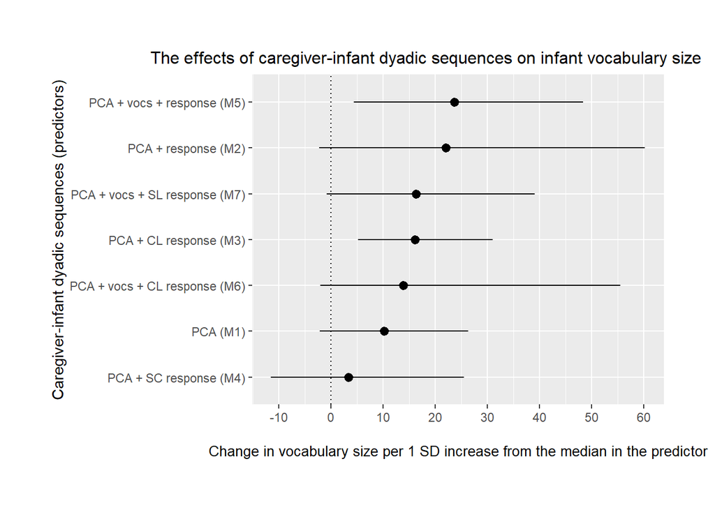

```r
# Creating a ggplot with the effect size data
p <- ggplot(data = my_table1,
            aes(x = reorder(variable, IQR_above_median),
                y = IQR_above_median, ymin = lower, ymax = upper)) +
  scale_y_continuous(breaks = seq(-20, 70, by = 10)) + # setting the units of the y axis
  geom_hline(yintercept = 0, linetype = "dotted", color = "black") + # dotted line at 0 point on the y axis
  geom_pointrange() + # drawing lines between lower and upper bound for each predictor
  coord_flip() + # rotating the axis
  labs(x = "Caregiver-infant dyadic sequences (predictors)",
       y = "Change in vocabulary size per 1 SD increase from the median in the predictor",
       title = "The effects of caregiver-infant dyadic sequences on infant vocabulary size") + # the labels of the graph
  theme(axis.title.x = element_text(size = 10, margin = margin(t = 15)),
        plot.margin = unit(c(0.5, 0.5, 0.5, 0.5), "inches"),
        plot.title = element_text(size = 12, hjust = 0.73)) #Set the plot margins and the distance between the axis and the labels

p
```

```r
ggsave(here("figs", "plot.png"), plot = p) #Saving the plot as a PNG
```

### References

Donnellan, E., Bannard, C., McGillion, M. L., Slocombe, K. E., & Matthews, D. (2020). Infants’ intentionally communicative vocalizations elicit responses from caregivers and are the best predictors of the transition to language: A longitudinal investigation of infants’ vocalizations, gestures and word production. Developmental Science, 23(1), e12843. https://doi.org/10.1111/desc.12843

Repository for this project: https://github.com/paulgering/masters_project, Pre-registration for this project on the OSF: https://osf.io/t4r3u, Pre-registration for full RCT on the OSF: https://osf.io/kme68/